# Finding trends and patterns in consumer spending

Author: Younkyung Lee

**Objective:** The main purpose of this analysis is to find spending patterns across prominent consumer markets using Consumer Expenditure Survey data from the National Bureau of Economic Research (http://www.nber.org/data/ces_cbo.html). I am assuming that the client is interested in the broad patterns of the consumer markets.

**About the Data:** The Consumer Expenditure Surveys (CE) provides data on expenditures, income, and demographic characteristics of consumers in the United States. The survey is self-administered, and each consumer unit keeps a diary for two one-week periods. This survey is meant to capture small, frequently purchased items and allows respondents to record all purchases such as spending for food and beverages, tobacco, personal care products, and nonprescription drugs and supplies. This survey is also designed to be representative of the entire U.S. civilian non-institutionalized population, and includes both urban and rural areas.

**Questions:** In this analysis, I am going to focus on the demographics of the respondent, the size of the respondent’s household, the income of the respondent , and total expenditures on food (fruits, vegetable, groceries), alcohol and non-alcohol beverages. The specific questions will be answered below.

## Step 0: Set working directory and install packages.

## Step 1: Load data

First, import the zip file data set from the Bureau of Labor Statistics (BLS) web page into a data frame:

```r
#import consumer expenditure data
download.file("https://www.bls.gov/cex/pumd/data/comma/diary21.zip", "diary21.zip")

diary_df <- list("diary21/fmld211.csv",
             "diary21/fmld212.csv",
             "diary21/fmld213.csv",
             "diary21/fmld214.csv") %>%
  map_dfr(~read_csv(unz("diary21.zip", .x)) %>%
            mutate_all(as.character))
```

The main data frame has 381 columns and 12067 observations.

```r
#glimpse at data
dim(diary_df)
```

```
[1] 12067   381
```

```r
#glimpse at data
head(diary_df)
```

```
# A tibble: 6 × 381
  INC_RNKM INC_R…¹ INC_R…² INC_R…³ INC_R…⁴ INC_R…⁵ INC_R…⁶ NEWID AGE_REF AGE_R…⁷
  <chr>    <chr>   <chr>   <chr>   <chr>   <chr>   <chr>   <chr> <chr>   <chr>
1 0.35716… 0.3644… 0.3697… 0.3690… 0.3605… 0.3675… 0.4607… 0469… 28      D
2 0.35792… 0.3652… 0.3705… 0.3697… 0.3612… 0.3683… 0.4614… 0469… 28      D
3 0.812407 0.8191… 0.79566 0.7904… 0.7969… 0.8391… 0.8566… 0469… 42      D
4 0.82830… 0.8302… 0.8337… 0.8087… 0.8306… 0.8167… 0.8563… 0469… 42      D
5 0.66860… 0.6668… 0.6669… 0.6670… 0.6611… 0.6684… 0.7246… 0469… 80      D
6 0.66882  0.6671… 0.6671… 0.6672… 0.6614… 0.6686… 0.7248… 0469… 80      D
# … with 371 more variables: AGE2 <chr>, AGE2_ <chr>, BLS_URBN <chr>,
#   CUTENURE <chr>, CUTE_URE <chr>, DESCRIP <chr>, DESCRIP_ <chr>,
#   EARNCOMP <chr>, EARN_OMP <chr>, EDUC_REF <chr>, EDUC0REF <chr>,
#   EDUCA2 <chr>, EDUCA2_ <chr>, EMPLTYP1 <chr>, EMPL_YP1 <chr>,
#   EMPLTYP2 <chr>, EMPL_YP2 <chr>, FAM_SIZE <chr>, FAM__IZE <chr>,
#   FAM_TYPE <chr>, FAM__YPE <chr>, FGVX <chr>, FGVX_ <chr>, FINCBEFX <chr>,
#   FINC_EFX <chr>, FINLWT21 <chr>, FIRAX <chr>, FIRAX_ <chr>, …
```

As we do not have any information of the variable names, let’s import the dictionary data set:

```r
dict<-read_csv('dictionary.csv', show_col_types = FALSE)
```

```r
#glimpse at data
head(dict)
```

```
# A tibble: 6 × 2
  VarName Description
  <chr>   <chr>
1 ADDFEDX Amount of federal tax paid by any CU member in addition to that withh…
2 ADDOTHX Amount of other taxes paid which were not reported elsewhere during p…
3 ADDSTAX Amount of state and local tax paid in addition to that withheld from …
4 AGE     What is the member's age?
5 AGE     What is the member's age?
6 AGE_REF Age of reference person
```

To easily search for the meaning of the variable, I made a function that returns the meaning.

```r
#function to easily match variable names to the details.
find_var_mean <- function(dict, varname) {
  meaning<- head(dict[dict['VarName'] == varname,],1)
  return(meaning)
}

# e.g. to find the description of AGE
find_var_mean(dict, 'AGE')
```

```
# A tibble: 1 × 2
  VarName Description
  <chr>   <chr>
1 AGE     What is the member's age?
```

```r
# e.g. to find the description of FOODTOT
find_var_mean(dict, 'FOODTOT')
```

```
# A tibble: 1 × 2
  VarName Description
  <chr>   <chr>
1 FOODTOT Total Food Expenditure
```

Using the function above, I want to extract the data that I need. As mentioned above, I aim to focus on:

**Demographic:** age, sex, region, the size of the respondent’s household, age of children, the number of children in the household under the age of 15, the income of the respondent.

**Spending:** total expenditures on food, alcohol/non-alcoholic beverages, bakery products, beef, pork, poulty, cereal, housekeeping supplies and services.

```r
#demographic
demo_df<-diary_df[,c('NEWID','AGE_REF','INC_RNKM','BLS_URBN', 'EDUC_REF','FAM_SIZE','CHILDAGE','FAM_TYPE')]

head(demo_df)
```

```
# A tibble: 6 × 8
  NEWID    AGE_REF INC_RNKM  BLS_URBN EDUC_REF FAM_SIZE CHILDAGE FAM_TYPE
  <chr>    <chr>   <chr>     <chr>    <chr>    <chr>    <chr>    <chr>
1 04690611 28      0.3571698 1        12       2        0        9
2 04690612 28      0.3579267 1        12       2        0        9
3 04690621 42      0.812407  1        13       3        3        3
4 04690622 42      0.8283064 1        13       3        3        3
5 04690661 80      0.6686021 1        12       2        0        1
6 04690662 80      0.66882   1        12       2        0        1
```

```r
spending_df<-diary_df[,c('NEWID', 'FOODTOT','FOODAWAY','FOODHOME','ALCBEV','NONALBEV', 'BAKEPROD','BEEF', 'EGGS', 'FRSHFRUT','FRSHVEG','DRUGSUPP', 'HOUSKEEP', 'PORK','POULTRY')]

head(spending_df)
```

```
# A tibble: 6 × 15
  NEWID    FOODTOT   FOODAWAY FOODH…¹ ALCBEV NONAL…² BAKEP…³ BEEF  EGGS  FRSHF…⁴
  <chr>    <chr>     <chr>    <chr>   <chr>  <chr>   <chr>   <chr> <chr> <chr>
1 04690611 58.57     0        58.57   0      5       0       0     0     0
2 04690612 14        14       0       0      0       0       0     0     0
3 04690621 227.4     31.45    195.95  35.22  22.68   7.54    12.09 1.05  1.07
4 04690622 187.72    133.09   54.63   35.71  48.28   0       0     0     0
5 04690661 191.27998 60.28    130.99… 0      20.501… 11.900… 8.11… 5.68… 10.748…
6 04690662 82.99999  0        82.999… 0      0       0       0     0     0
# … with 5 more variables: FRSHVEG <chr>, DRUGSUPP <chr>, HOUSKEEP <chr>,
#   PORK <chr>, POULTRY <chr>, and abbreviated variable names ¹FOODHOME,
#   ²NONALBEV, ³BAKEPROD, ⁴FRSHFRUT
```

## Step 2: Clean Data

```r
#a look at demographic variables.

output <- summary(demo_df)
print(output)
```

```
    NEWID             AGE_REF            INC_RNKM           BLS_URBN
 Length:12067       Length:12067       Length:12067       Length:12067
 Class :character   Class :character   Class :character   Class :character
 Mode  :character   Mode  :character   Mode  :character   Mode  :character
   EDUC_REF           FAM_SIZE           CHILDAGE           FAM_TYPE
 Length:12067       Length:12067       Length:12067       Length:12067
 Class :character   Class :character   Class :character   Class :character
 Mode  :character   Mode  :character   Mode  :character   Mode  :character
```

All of the columns in demo_df are characters. We need to change some of the variables to integers.

```r
# to integer

demo_df$AGE_REF<-as.integer(demo_df$AGE_REF)
demo_df$FAM_SIZE<-as.integer(demo_df$FAM_SIZE)
demo_df$CHILDAGE<-as.integer(demo_df$CHILDAGE)
demo_df$EDUC_REF<-as.integer(demo_df$EDUC_REF)
demo_df$EDUC_REF<-as.integer(demo_df$INC_RNKM)
```

```r
#a look at demographic variables.

output <- summary(demo_df)
head(output)
```

```
    NEWID              AGE_REF        INC_RNKM           BLS_URBN
 Length:12067       Min.   :16.00   Length:12067       Length:12067
 Class :character   1st Qu.:38.00   Class :character   Class :character
 Mode  :character   Median :54.00   Mode  :character   Mode  :character
                    Mean   :53.08
                    3rd Qu.:67.00
                    Max.   :87.00
    EDUC_REF            FAM_SIZE         CHILDAGE       FAM_TYPE
 Min.   :0.0000000   Min.   : 1.000   Min.   :0.000   Length:12067
 1st Qu.:0.0000000   1st Qu.: 1.000   1st Qu.:0.000   Class :character
 Median :0.0000000   Median : 2.000   Median :0.000   Mode  :character
 Mean   :0.0003315   Mean   : 2.341   Mean   :1.548
 3rd Qu.:0.0000000   3rd Qu.: 3.000   3rd Qu.:3.000
 Max.   :1.0000000   Max.   :12.000   Max.   :7.000
```

Similarly, the datatype of spending_df needs some change.

```r
#a look at spending data

output <- summary(spending_df)
print(output)
```

```
    NEWID             FOODTOT            FOODAWAY           FOODHOME
 Length:12067       Length:12067       Length:12067       Length:12067
 Class :character   Class :character   Class :character   Class :character
 Mode  :character   Mode  :character   Mode  :character   Mode  :character
    ALCBEV            NONALBEV           BAKEPROD             BEEF
 Length:12067       Length:12067       Length:12067       Length:12067
 Class :character   Class :character   Class :character   Class :character
 Mode  :character   Mode  :character   Mode  :character   Mode  :character
     EGGS             FRSHFRUT           FRSHVEG            DRUGSUPP
 Length:12067       Length:12067       Length:12067       Length:12067
 Class :character   Class :character   Class :character   Class :character
 Mode  :character   Mode  :character   Mode  :character   Mode  :character
   HOUSKEEP             PORK             POULTRY
 Length:12067       Length:12067       Length:12067
 Class :character   Class :character   Class :character
 Mode  :character   Mode  :character   Mode  :character
```

Similarly, all of the columns in demo_df are characters. We need to change some of the variables to integers.

```r
# to integer

spending_df[,2:15] <- sapply(spending_df[,2:15], as.integer)
```

Check if it has changed correctly. We can see the average weekly expenditure for each categories.

```r
# check again

output <- summary(spending_df)
print(output)
```

```
    NEWID              FOODTOT          FOODAWAY          FOODHOME
 Length:12067       Min.   :   0.0   Min.   :   0.00   Min.   :   0
 Class :character   1st Qu.:  46.0   1st Qu.:   0.00   1st Qu.:  20
 Mode  :character   Median : 111.0   Median :  20.00   Median :  71
                    Mean   : 152.4   Mean   :  51.16   Mean   : 101
                    3rd Qu.: 212.0   3rd Qu.:  68.00   3rd Qu.: 145
                    Max.   :3850.0   Max.   :3758.00   Max.   :2589
     ALCBEV          NONALBEV          BAKEPROD            BEEF
 Min.   :   0.0   Min.   :  0.000   Min.   :  0.000   Min.   :  0.000
 1st Qu.:   0.0   1st Qu.:  0.000   1st Qu.:  0.000   1st Qu.:  0.000
 Median :   0.0   Median :  3.000   Median :  4.000   Median :  0.000
 Mean   :  10.2   Mean   :  9.706   Mean   :  8.749   Mean   :  5.358
 3rd Qu.:   0.0   3rd Qu.: 14.000   3rd Qu.: 12.000   3rd Qu.:  6.000
 Max.   :2178.0   Max.   :278.000   Max.   :710.000   Max.   :400.000
      EGGS           FRSHFRUT          FRSHVEG           DRUGSUPP
 Min.   : 0.000   Min.   :  0.000   Min.   :  0.000   Min.   :   0.000
 1st Qu.: 0.000   1st Qu.:  0.000   1st Qu.:  0.000   1st Qu.:   0.000
 Median : 0.000   Median :  2.000   Median :  2.000   Median :   0.000
 Mean   : 1.181   Mean   :  7.276   Mean   :  6.251   Mean   :   8.757
 3rd Qu.: 1.000   3rd Qu.: 10.000   3rd Qu.:  9.000   3rd Qu.:   0.000
 Max.   :90.000   Max.   :280.000   Max.   :247.000   Max.   :1998.000
    HOUSKEEP            PORK            POULTRY
 Min.   :   0.00   Min.   :  0.000   Min.   :  0.000
 1st Qu.:   0.00   1st Qu.:  0.000   1st Qu.:  0.000
 Median :   0.00   Median :  0.000   Median :  0.000
 Mean   :  15.78   Mean   :  4.154   Mean   :  3.742
 3rd Qu.:  16.00   3rd Qu.:  5.000   3rd Qu.:  5.000
 Max.   :1729.00   Max.   :286.000   Max.   :131.000
```

Let’s merge the two data sets.

```r
#merge data

merged_df<-merge(demo_df, spending_df, by.x = "NEWID")

head(merged_df)
```

```
     NEWID AGE_REF  INC_RNKM BLS_URBN EDUC_REF FAM_SIZE CHILDAGE FAM_TYPE
1 04690611      28 0.3571698        1        0        2        0        9
2 04690612      28 0.3579267        1        0        2        0        9
3 04690621      42  0.812407        1        0        3        3        3
4 04690622      42 0.8283064        1        0        3        3        3
5 04690661      80 0.6686021        1        0        2        0        1
6 04690662      80   0.66882        1        0        2        0        1
  FOODTOT FOODAWAY FOODHOME ALCBEV NONALBEV BAKEPROD BEEF EGGS FRSHFRUT FRSHVEG
1      58        0       58      0        5        0    0    0        0       0
2      14       14        0      0        0        0    0    0        0       0
3     227       31      195     35       22        7   12    1        1       6
4     187      133       54     35       48        0    0    0        0       0
5     191       60      130      0       20       11    8    5       10       0
6      82        0       82      0        0        0    0    0        0       9
  DRUGSUPP HOUSKEEP PORK POULTRY
1        0       11    0       7
2        0        0    0       0
3        0        3    6      11
4        0        0    0       0
5        0        0    0       0
6        0        0    0       0
```

Lastly, look for missing of duplicate variables.

Identify duplicate rows.

```r
merged_df[duplicated(merged_df), ]
```

```
 [1] NEWID    AGE_REF  INC_RNKM BLS_URBN EDUC_REF FAM_SIZE CHILDAGE FAM_TYPE
 [9] FOODTOT  FOODAWAY FOODHOME ALCBEV   NONALBEV BAKEPROD BEEF     EGGS
[17] FRSHFRUT FRSHVEG  DRUGSUPP HOUSKEEP PORK     POULTRY
<0 행> <또는 row.names의 길이가 0입니다>
```

Seems like there is no duplicates.

Now let’s identify the missing variables.

```r
# replace missing value(99) with NA

merged_df %>% replace_with_na(replace = list(x = c(99, '99')))

output <- summary(merged_df)
print(output)
```

[output not shown]

```r
p <- function(x) {sum(is.na(x))/length(x)*100}
apply(merged_df, 2, p)
```

```
   NEWID  AGE_REF INC_RNKM BLS_URBN EDUC_REF FAM_SIZE CHILDAGE FAM_TYPE
       0        0        0        0        0        0        0        0
 FOODTOT FOODAWAY FOODHOME   ALCBEV NONALBEV BAKEPROD     BEEF     EGGS
       0        0        0        0        0        0        0        0
FRSHFRUT  FRSHVEG DRUGSUPP HOUSKEEP     PORK  POULTRY
       0        0        0        0        0        0
```

There is no missing value.

## Question 1: Dine Out vs Eating from home

First, I am going to explore the general trends of dining patterns. For instance, do US citizens spend more money for eating out or eating from home? Does this rate differ by cities compared to rural areas?

Let’s explore the total expenditure spent on food and how the amount differs for each category (dining out vs eating from home).

```r
summary(merged_df[c('FOODTOT','FOODAWAY','FOODHOME')])
```

```
    FOODTOT          FOODAWAY          FOODHOME
 Min.   :   0.0   Min.   :   0.00   Min.   :   0
 1st Qu.:  46.0   1st Qu.:   0.00   1st Qu.:  20
 Median : 111.0   Median :  20.00   Median :  71
 Mean   : 152.4   Mean   :  51.16   Mean   : 101
 3rd Qu.: 212.0   3rd Qu.:  68.00   3rd Qu.: 145
 Max.   :3850.0   Max.   :3758.00   Max.   :2589
```

From the average value, we can see that people spend more money for eating at home. Remember this survey was conducting during COVID. To get a better picture, we should see the distribution of the data.

However, before moving on get rid of the outliers.

```r
merged_df_cut<-merged_df[(merged_df['FOODTOT']<212) & (merged_df['FOODTOT']>46),]
```

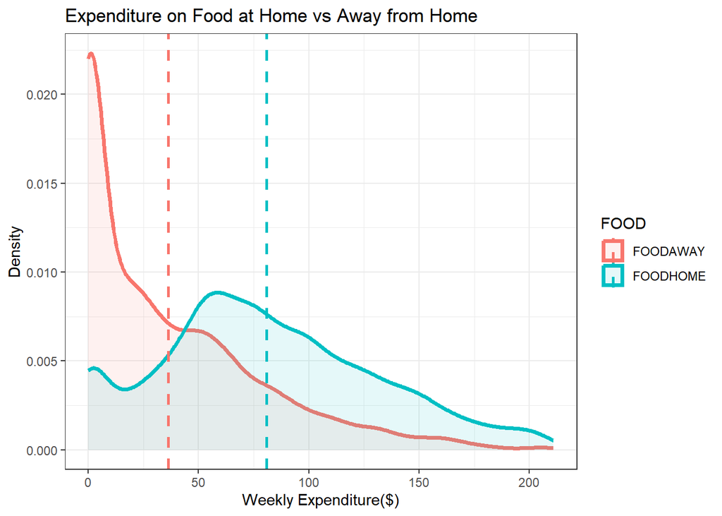

```r
df_dine <- merged_df_cut %>% gather(key = FOOD, value = Value, FOODAWAY:FOODHOME)

# Find the mean of each group
library(plyr)
cdat <- ddply(df_dine, "FOOD", summarise, value.mean=mean(Value))

# Density plots with means
ggplot(df_dine, aes(x=Value, fill = FOOD,colour=FOOD)) +
    geom_density(size = 1.4, alpha =0.1) +
    geom_vline(data=cdat, aes(xintercept=value.mean,  colour=FOOD),
               linetype="dashed", size= 1) +
    ggtitle('Expenditure on Food at Home vs Away from Home') +
    xlab('Weekly Expenditure($)') +
    ylab('Density') +
    scale_fill_brewer(palette = "Dark2") +
    theme_bw() +
    scale_fill_hue()
```

The average weekly expenditure for food is $152. People spend more in buying food for eating at home($101) vs away ($51). Because this is data from 2021 and during COVID, it would be interesting to compare this data to the patterns of 2019.

## Question 2: Urban-Rural Differences in food consumption

[figure not shown]

```r
#plot dining in vs out in cities and rural areas

ggplot(df_dine, aes(x= BLS_URBN, y=Value, fill=FOOD)) +
    geom_boxplot() +
    ggtitle("") + xlab("") +ylab("") +
    scale_x_discrete(name ="Urbanization", labels=c("Urban", "Rural")) +
    scale_fill_discrete(name = "Dining Location", labels = c("Home", "Restaurant")) +
    theme_bw()
```

## Question 3: Income Range and Fresh Food

Next, let’s find out whether people who earn more income spend more money in fresh food (such as fresh vegetables, fresh fruits) vs others (eggs)?

```r
ff_df<-merged_df[, c('INC_RNKM','FOODTOT', 'EGGS', 'FRSHFRUT','FRSHVEG')]
ff_df$INC_RNKM<-as.integer(ff_df$INC_RNKM)
```

```r
# correlation matrix
cor(ff_df)
```

```
           INC_RNKM    FOODTOT       EGGS   FRSHFRUT    FRSHVEG
INC_RNKM 1.00000000 0.04680592 0.00539085 0.03024151 0.02206958
FOODTOT  0.04680592 1.00000000 0.37944024 0.52240292 0.48118501
EGGS     0.00539085 0.37944024 1.00000000 0.30531475 0.28627978
FRSHFRUT 0.03024151 0.52240292 0.30531475 1.00000000 0.49071677
FRSHVEG  0.02206958 0.48118501 0.28627978 0.49071677 1.00000000
```

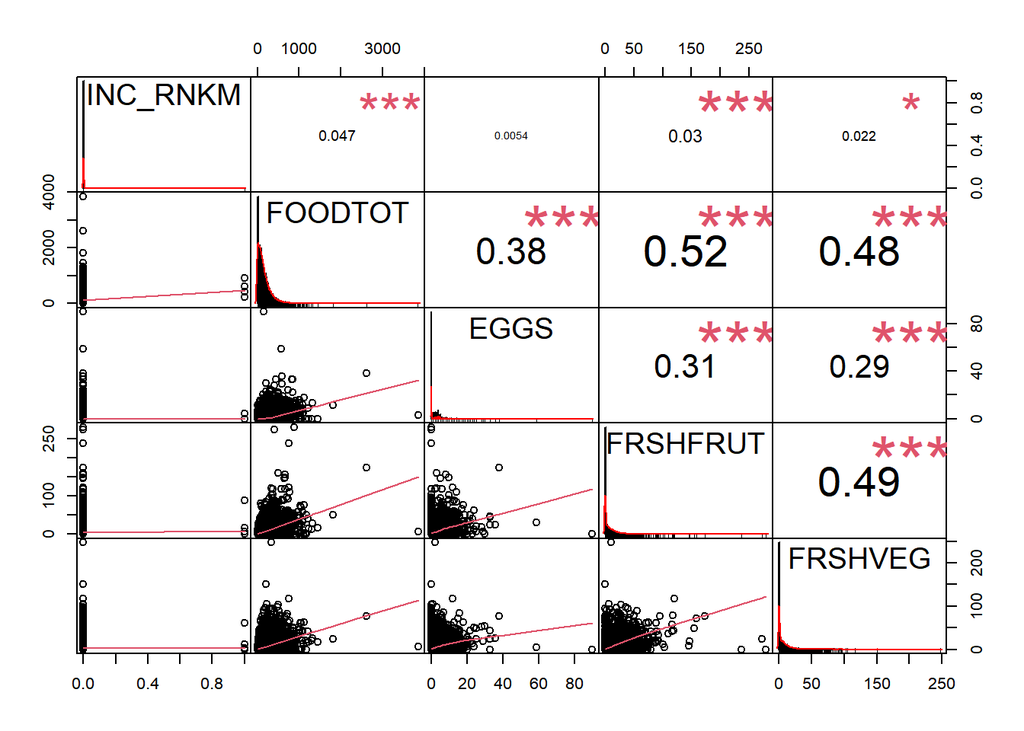

```r
# plot the data
library(PerformanceAnalytics)
chart.Correlation(ff_df)
```

Similarly, there is no direct link between income and expenditure on meat

```r
ff_df<-merged_df[, c('INC_RNKM', 'BEEF', 'POULTRY','PORK')]
ff_df$INC_RNKM<-as.integer(ff_df$INC_RNKM)

# correlation matrix
cor(ff_df)
```

```
            INC_RNKM        BEEF     POULTRY        PORK
INC_RNKM 1.000000000 0.003766889 0.008177609 0.003168758
BEEF     0.003766889 1.000000000 0.253503724 0.349546613
POULTRY  0.008177609 0.253503724 1.000000000 0.239878453
PORK     0.003168758 0.349546613 0.239878453 1.000000000
```

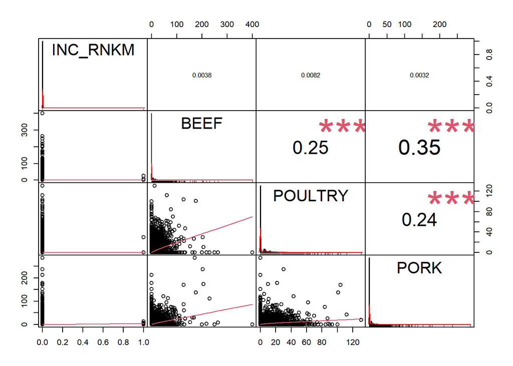

```r
# plot the data
library(PerformanceAnalytics)
chart.Correlation(ff_df)
```

## Question 4: Alcohol and Healthy Behavior

```r
df_bev <- merged_df %>% gather(key = "BEV", value = Value, ALCBEV:NONALBEV)
df_bev<-df_bev[(df_bev['Value']<100) &(df_bev['Value']>0),]
```

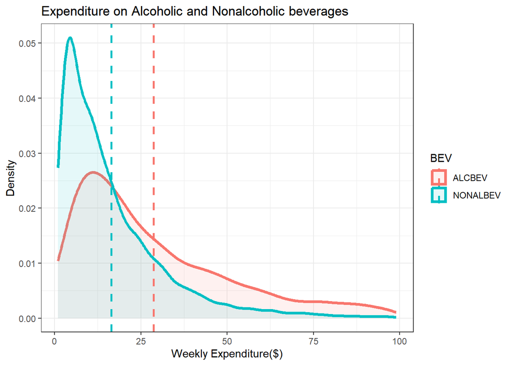

```r
# Find the mean of each group
library(plyr)
cdat <- ddply(df_bev, "BEV", summarise, value.mean=mean(Value))

# Density plots with means
ggplot(df_bev, aes(x=Value, fill = BEV, colour= BEV)) +
    geom_density(size = 1.4, alpha =0.1) +
    geom_vline(data=cdat, aes(xintercept=value.mean,  colour= BEV),
               linetype="dashed", size= 1) +
    ggtitle('Expenditure on Alcoholic and Nonalcoholic beverages') +
    xlab('Weekly Expenditure($)') +
    ylab('Density') +
    scale_fill_brewer(palette = "Dark2") +
    theme_bw() +
    scale_fill_hue()
```

```r
health_df<-merged_df[, c('INC_RNKM','ALCBEV', 'NONALBEV','FRSHFRUT','FRSHVEG')]
health_df$INC_RNKM<-as.integer(health_df$INC_RNKM)

# correlation matrix
cor(health_df)
```

```
            INC_RNKM     ALCBEV    NONALBEV   FRSHFRUT    FRSHVEG
INC_RNKM 1.000000000 0.02647480 0.006732912 0.03024151 0.02206958
ALCBEV   0.026474801 1.00000000 0.099157992 0.08299119 0.09004373
NONALBEV 0.006732912 0.09915799 1.000000000 0.36280115 0.28218285
FRSHFRUT 0.030241506 0.08299119 0.362801153 1.00000000 0.49071677
FRSHVEG  0.022069582 0.09004373 0.282182852 0.49071677 1.00000000
```

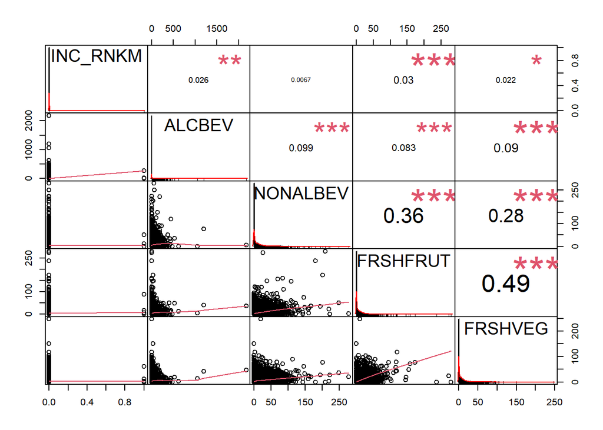

```r
# plot the data
chart.Correlation(health_df)
```

## Conclusion and Discussion

This report provides a brief analysis of spending patterns across specific food and beverage categories using Consumer Expenditure Survey data from the National Bureau of Economic Research. Based on the findings above, the analysis can be further expanded by incorporating longitudinal data and price-index data.